#### Title: The Effect of Income on Religiousness [Replication Project]

##### Author: Gigi Lin

##### Date: December 4, 2017

> Part I: Introduction

Thomas Buser uses self-collected survey data to analyze the effects of income shocks on religious behavior. He undertakes a regression discontinuity design on the change in eligibility for a government cash transfer on 3 income measures: attendance per month, identification with Evangelical Christianity, and self-rating of religiousness. The paper and dataset were retrieved from [here](https://www.aeaweb.org/articles?id=10.1257/app.20140162). There are 3 questions to be answered in this paper:  
1. Do people become more or less religious when they become richer?  
2. Do people change their religion as they become richer?  
3. Do people change attendance frequency as they become richer?

There have been studies done that show how religion has effects on individuals, but this paper attempts to investigate the reverse relationship. Buser asserts his paper as the first of its kind to look at this pivotal relationship. Usually, in a randomized experiment, people are randomized to a treatment and control group. RDD employs a discontinuous assignment rule that randomizes in determining whether households are placed in the treatment or control group. As Ecuador is a lower middle income country with high poverty levels and high inequality, the eligibility of the government cash transfer program may have significant income effects on poorer households. Depending on where a household is initially placed within the wealth index, it asserts their position to receive the transfer.

This paper is interesting as it looks at the institutional rule of sorting households into either group, and whether the income increase results in statistically significant changes in attendance, identification, or self-rated religiousness. The idea is to compare households that just ‘miss’ the cutoff to those that just ‘make’ the cutoff. The only difference between the households near the threshold is that one receives the treatment whereas the other does not. The difference in status allows us to uncover the treatment effect.

> Part II: Data Description

The survey consists of randomly sampled households from poor neighborhoods in 3 urban centers: Guayaquil, Quito, and Santo Domingon. The survey takers collected data on characteristics of households such as: age of the responder, education level of the responder, amount spent on expenditures, their affiliation with religious services, and more. The **SELBEN-II (s2)** survey was conducted around 4-5 years after the initial start. The data is relevant as households were randomly sampled within each city and within the same government parish. This helped ensure the groups were geographically balanced. In addition, in randomly sampling 2645 households, this decreased the probability of selection bias that households whom received the transfer were different from those whom didn’t.

```r
library(tidyverse)
library(rdd)
library(rdrobust)
require(gridExtra)
rm(list=ls())
```

The descriptive statistics are presented in Table 2. Since no data repository was provided, I went through and corresponded frequencies of each variable with their respective meaning (i.e.: denomination of “1” == Catholic). The sample means and standard deviations are also provided.

##### Table 2: Descriptive Statistics - Religion

```
##                        Obsv     Percent
## Catholic               1971 74.51795841
## Non-Catholic Christian  452 17.08884688
## Jewish                    2  0.07561437
## Atheist/none             53  2.00378072
## Other                   167  6.31379962
```

##### Table 2: Descriptive Statistics - Service Attendance

```
##                   Obsv   Percent
## Never              192  7.258979
## Special Occasions  310 11.720227
## < 1 month          138  5.217391
## Once/month         324 12.249527
## 2-3 times/month    507 19.168242
## Once/week          738 27.901701
## 2-3 times/week     257  9.716446
## 4-6 times/week     106  4.007561
## Every day           73  2.759924
```

##### Table 2: Means and Standard Deviations

```
##                       Means    SD
## Attendance/mth        4.318904 6.142649
## Religiousness         6.827599 2.37958
## Household size        4.46276  1.969086
## Age                   42.71871 11.0413
## Years of schooling    7.446388 3.686763
## Household expenditure 297.2648 151.3583
```

> Part III: Model and Results: OLS

I first use sharp RDD methods in segregating households based on their s2 scores. In sharp RDD, being below/above the cutoff (`score2_1`) means the observation (household) is in the treatment/control group. So Buser randomizes households on eligibility criteria if their s2 < 0 (eligible = 1), and ineligible if s2 > 0 (eligible = 0). The strict inequality does not change the group composition. When we are running regression analyses, the coefficient on the `eligible` binary indicator will be the estimate of the treatment effect.

```r
ir_new <- ir_df %>%  mutate(eligible = case_when(score2_1 >= 0 ~ 0, # not eligible
                               score2_1 < 0 ~ 1)) # eligible
```

There is an ineligibility/eligibility issue.

```
## [1] 38
```

```
## [1] 193
```

We find that there were 38 households eligible, but did not collect the transfer, and 193 households were ineligible, but still received the transfer. The sample size for all regressions in the paper was still 2645 - the size of the original dataset, so I have decided to bypass losing df by not removing these observations. However, I postulate this is the reason as to why Buser uses fuzzy RDD as households’ status is not solely determined by their s2. This will also result in different coefficient estimates in later regressions compared to Buser’s results.

Buser uses the model:
$$Y = α + δeligible + f(s) + β(score2_1) + controls$$
**Define the variables as:**
$Y$: income measure
$eligible$: whether the household is eligible or not
$f(s)$: conditioning on the polynomial in $score2_1$
$score2_1$: SELBEN-II score

Let us first try fitting a linear model on the dataset. The asssumptions of no endogeneity and serial correlation seem valid in this model as the zero conditional mean is satisfied. The errors have expectation zero as the s2 is determined exogeneous to the model and cannot be manipulated. In our OLS regression, I have decided to include score2_2 (score2_1*eligible) as a way to look at the effects of eligibility on s2. In addition, Buser controls for eligibility before the change (`moremoneyold`).

The following uses the **1st-order polynomial:**

```
##                 Estimate Std. Error  t value    Pr(>|t|)
## Church_Attend 1.38981721 0.48014072 2.894604 0.003827525
## Evangelical   0.05128881 0.02945199 1.741438 0.081723341
## Religiousness 0.20289451 0.18621082 1.089596 0.275990732
```

We see that at the 1% significance level, recipients spend about 1.39 more days at church services than non-recipients. At the 10% significant level, recipients are 5.12% percentage points more likely to be Evangelical.

Let us conduct further regressions on different order polynomials of the s2 (score2_1) and income measures.

The following uses the **2nd-order polynomial:**

```
##                 Estimate Std. Error  t value    Pr(>|t|)
## Church_Attend 1.37508248 0.47886873 2.871523 0.004117552
## Evangelical   0.05193934 0.02937272 1.768285 0.077128797
## Religiousness 0.20027417 0.18571410 1.078400 0.280953603
```

The following uses **3rd-order polynomial:**

```
##                 Estimate Std. Error   t value  Pr(>|t|)
## Church_Attend 1.01581362 0.40059788 2.5357439 0.0112781
## Evangelical   0.03543929 0.02456966 1.4424003 0.1493081
## Religiousness 0.13547804 0.15537629 0.8719351 0.3833231
```

Buser uses a binned approach to segregate households by their s2 scores. Let us try plotting the relationship between  
(i) score2_1 & attendpermonth  
(ii) score2_1 & protestant

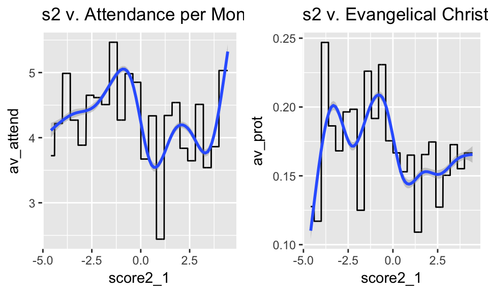

```r
grid.arrange(v1plot, v2plot, ncol=2)
```

We see that by using the auto-fit line method, it exhibits a polynomial relationship between s2 and `attendpermonth`, similarly with s2 and `protestant`. There is a sharp drop in the slope of the best-fit line around s2=0. This could potentially mean a higher order polynomial regression will fit the relationship better.

3. score2_1 & religiousness

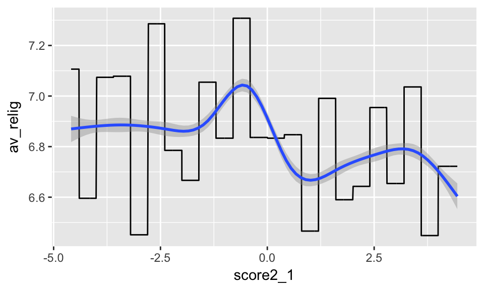

```r
v3plot
```

Getting similar results to (i) and (ii) from above. Using OLS is not plausible as Linear regression is not a good estimation technique to analyze the effects of eligibility for cash transfer as below and above the cutoff of s2 = 0, there is a noticeable difference in the slopes; a best-fit line with a constant slope cannot properly depict the effect of eligibility.

Let’s examine the relationship by plotting some Regression Discontinutiy (RD) plots between the income measure (Y) and the s2:

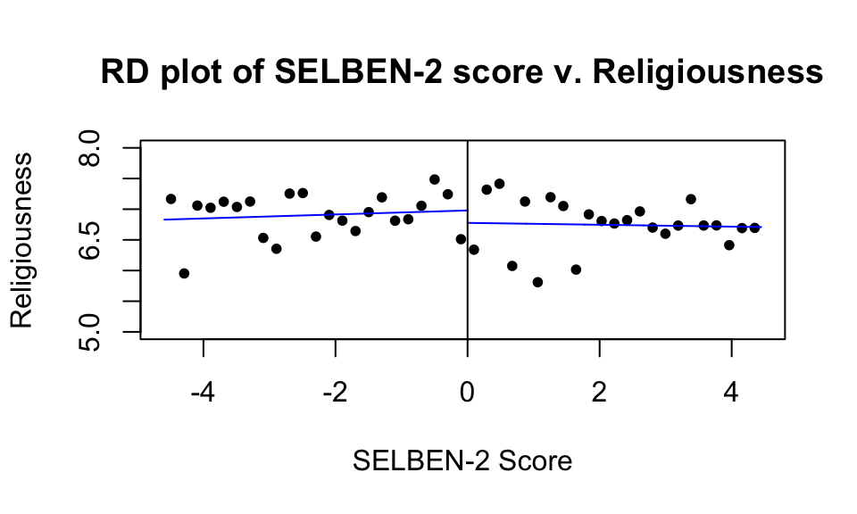

```
## Call: rdplot
##
## Number of Obs.                 2645
## Kernel                          uni
##
## Number of Obs.                1344           1301
## Eff. Number of Obs.           1344           1301
## Order poly. fit (p)              1              1
## BW poly. fit (h)             4.591          4.446
## Number of bins scale             0              0
```

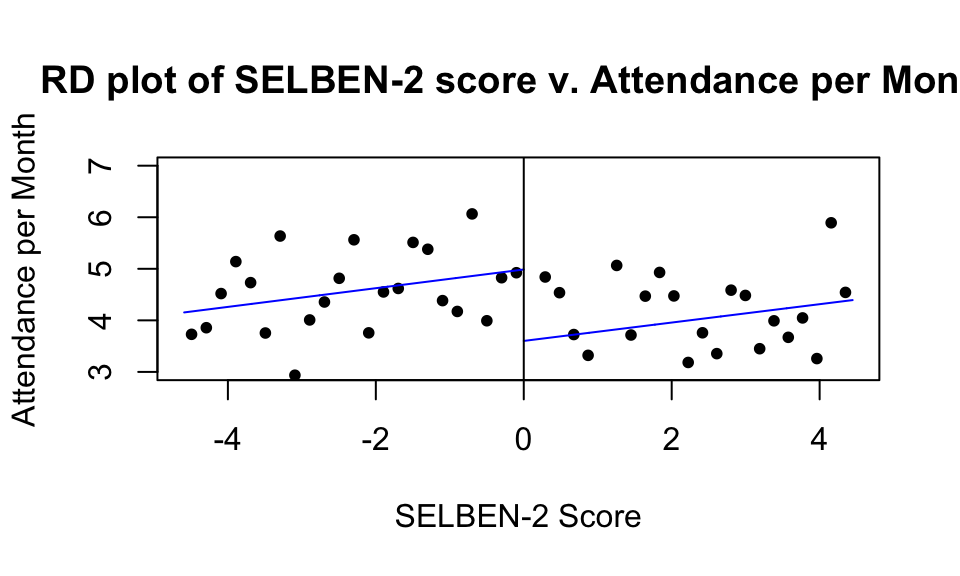

```
## Call: rdplot
##
## Number of Obs.                 2645
## Kernel                          uni
##
## Number of Obs.                1344           1301
## Eff. Number of Obs.           1344           1301
## Order poly. fit (p)              1              1
## BW poly. fit (h)             4.591          4.446
## Number of bins scale             0              0
```

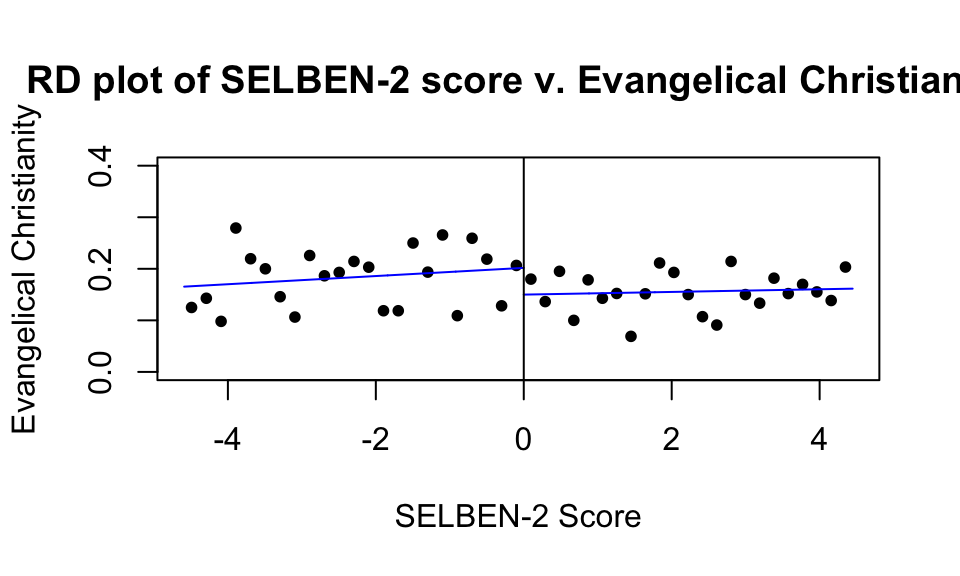

```
## Call: rdplot
##
## Number of Obs.                 2645
## Kernel                          uni
##
## Number of Obs.                1344           1301
## Eff. Number of Obs.           1344           1301
## Order poly. fit (p)              1              1
## BW poly. fit (h)             4.591          4.446
## Number of bins scale             0              0
```

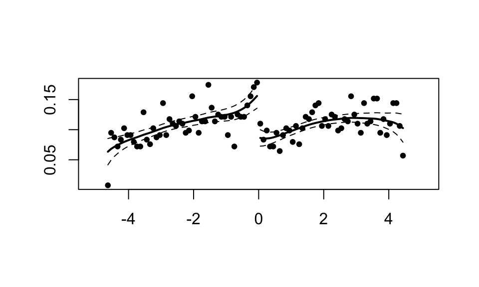

```
## [1] 6.898781e-06
```

We see that there is a clear discontinuity in the density of s2, and this suggests that possibly some households were able to manipulate their treatment status. Manipulation as in some households were able to determine their position on the SELBEN-II index and reported a lower income status in order to receive the cash transfer. If this is true, it violates a main assumption of RDD in that individuals cannot manipulate their x value (i.e. households cannot manipulate their s2 to fall within the eligibility treatment group).

** Some possible explanations of manipulation may be that households in previous years received the cash transfer, and knowing the SELBEN-II index may be changed, may bias their income estimates downwards in order to ensure they receive it.**

> Part IV: Advanced OLS & Results

From Part III we see that using linear regression of Y (income measure) on X with other control variables can be severely biased for the causal effect of X on Y due to endogeneity. Since there may be different impacts based on being in the treatment or cuttoff group, we want instead to only examine the treatment effect around s2=0. To do this, we can use RDD to look at the effects of the treatment based on the running (forcing) variable of interest.

RDD consists of sharp and fuzzy RDD. Sharp RDD is where all units below or above a threshold become treated, whereas the other half do not. Fuzzy RDD is a bit more complex in that the running variable being above/below a threshold only increases the *probability* of being treated, with other factors also influencing whether you actually get treated or not. We can think of sharp RDD as a selection-on-observables situation, whereas fuzzy RD is an IV-type setup.

Some assumptions in RDD are that: - Assignment to treatment and control isn’t random, but whether individual observation is treated is assumed to be random - Buser assumed that households cannot perfectly manipulate their s2 - As a result, whether a household becomes eligible or not is random

I want to augment my analysis of the linear form by using an Instrumental Variable approach and trying a different model specification than the one Buser uses in the paper (within reason).

#### 1. Instrumental Variable Regression

Fuzzy RDD means there is a higher probability of being in the treatment group. It can happen when there is a publicly suggested cutoff that’s not enforced. We see this where some whom were eligible, did not collect - and the converse also being true. Let us estimate the causal effect of receiving the cash-benefit on attendance by 2SLS and instrumenting collect_2 (Z) with eligible while controlling for the running variables. This will allow us to investigate whether collect_2 was a valid variable in Buser’s regression model above.

**2SLS**  
First stage: regress X on Z  
Second stage: regress Y on fitted values (Y-hat)  
IV model: Y (income measure) = b0 + b1*eligible + score2_1 + Z

```
##              Estimate Std. Error   t value      Pr(>|t|)
## (Intercept) 3.9992125  0.1763587 22.676579 3.571257e-104
## varX        0.7111715  0.2887285  2.463115  1.383690e-02
```

```
##               Estimate Std. Error   t value     Pr(>|t|)
## (Intercept) 0.15500156 0.01081519 14.331839 6.392155e-45
## varX        0.03534136 0.01770626  1.995981 4.603847e-02
```

```
##              Estimate Std. Error   t value   Pr(>|t|)
## (Intercept) 6.7349484 0.06834419 98.544557 0.00000000
## varX        0.2061071 0.11189081  1.842038 0.06558156
```

In using IV, we find that households whom collect cash benefits increase the number of church attendances by 0.71 days per month. This is the average effect for people who collect the benefit because they are eligible (the compliers). This seems likely and consistent with Buser’s other results as a positive income shock allows for increased time to attend services and a higher status.

#### 2. Misspecified model:

Buser may not have included all variables that have explanatory power on Y. By including more explanatory variables that appear to explain Y, we can control for the X’s and hopefully decrease omitted variable bias. As Ecuador is a relatively poor country, an increase in income could result in increased expenditure for the household. Usually, most of it is spent on children to close the gap caused by poverty [read more here](http://www.stuff.co.nz/dominion-post/comment/75556427/the-myth-of-how-families-in-poverty-spend-their-money). I want to look at level-log form to see if Y can be better explained by a change in the model. I will log the 3 variables below and look at their changes in p-value and coefficient estimate: - householdsize - education - expenditures

```
##
## Call:
## lm(formula = attendpermonth ~ schooling_resp + householdsize +
##     expenditures + expenditures + eligible + score2_1, data = ir_test)
##
## Residuals:
##     Min      1Q  Median      3Q     Max
## -5.2382 -3.6832 -1.5624 -0.0838 26.5262
##
## Coefficients:
##                  Estimate Std. Error t value Pr(>|t|)
## (Intercept)     3.8254888  0.4941842   7.741 1.42e-14 ***
## schooling_resp -0.0385527  0.0362187  -1.064   0.2872
## householdsize  -0.0187031  0.0687971  -0.272   0.7858
## expenditures    0.0006499  0.0008823   0.737   0.4615
## eligible        1.2316352  0.4850509   2.539   0.0112 *
## score2_1        0.1580728  0.0950050   1.664   0.0963 .
## ---
## Signif. codes:  0 '***' 0.001 '**' 0.01 '*' 0.05 '.' 0.1 ' ' 1
##
## Residual standard error: 6.085 on 2499 degrees of freedom
## Multiple R-squared:  0.003587,   Adjusted R-squared:  0.001593
## F-statistic: 1.799 on 5 and 2499 DF,  p-value: 0.1097
```

```
##
## Call:
## lm(formula = attendpermonth ~ leduc + lhhs + lexp + eligible +
##     score2_1, data = ir_test)
##
## Residuals:
##     Min      1Q  Median      3Q     Max
## -5.5342 -3.6724 -1.5614 -0.0625 26.5472
##
## Coefficients:
##             Estimate Std. Error t value Pr(>|t|)
## (Intercept)  3.88122    1.43802   2.699   0.0070 **
## leduc       -0.37348    0.21103  -1.770   0.0769 .
## lhhs        -0.12713    0.32538  -0.391   0.6960
## lexp         0.11671    0.28063   0.416   0.6775
## eligible     1.23200    0.48486   2.541   0.0111 *
## score2_1     0.16045    0.09492   1.690   0.0911 .
## ---
## Signif. codes:  0 '***' 0.001 '**' 0.01 '*' 0.05 '.' 0.1 ' ' 1
##
## Residual standard error: 6.083 on 2499 degrees of freedom
## Multiple R-squared:  0.004304,   Adjusted R-squared:  0.002312
## F-statistic: 2.161 on 5 and 2499 DF,  p-value: 0.05579
```

We see that in using the level-log form, `leduc` seems effective at capturing some of the effects on Y, as the p-value has decreased by 75%. We can run a regression to see the relationship of leduc on attendance.

```
##
## Call:
## lm(formula = attendpermonth ~ ir_test$leduc + score2_1, data = ir_test)
##
## Residuals:
##     Min      1Q  Median      3Q     Max
## -5.1487 -3.6561 -1.6499 -0.1596 26.2659
##
## Coefficients:
##               Estimate Std. Error t value Pr(>|t|)
## (Intercept)    4.98138    0.42061  11.843   <2e-16 ***
## ir_test$leduc -0.36364    0.20946  -1.736   0.0827 .
## score2_1      -0.04628    0.04759  -0.973   0.3309
## ---
## Signif. codes:  0 '***' 0.001 '**' 0.01 '*' 0.05 '.' 0.1 ' ' 1
##
## Residual standard error: 6.087 on 2502 degrees of freedom
## Multiple R-squared:  0.001634,   Adjusted R-squared:  0.0008357
## F-statistic: 2.047 on 2 and 2502 DF,  p-value: 0.1293
```

> Part V: Conclusion

**Summarize approach and findings:**  
Based on the results I obtained using linear regression, the coefficient values are similar when compared to Table 4. Buser concludes that a difference in income does affect families and their frequency of church services and on the type of church they attend, and no effect on how religious people rate themselves to be. Although I was not able to perform a fuzzy RDD properly or determine the threshold treatment effect difference at s2=0, I obtained similar findings.

**i. Noisy weights:** weights have unattractive properties and the higher the coefficient estimate, the more sensitive the estimate is to the order of the polynomial. We see this in the coefficient of `attendpermonth`, as the standard errors almost increase by 2-fold in polynomial order 1 vs. polynomial order 3 (Buser’s Table 4).  
**ii. Estimates become highly sensitive to the degree of the polynomial:** this is partly due to reason (i) above, and the confidence intervals become larger than necessary.  
**iii. Inferences are not able to achieve nominal coverage:** the global polynomial approximations are not precise enough so that bias can be ignored when estimating the treatment effect. Although my coefficient estimates were similar to Buser’s, my standard errors decrease as the poly order increases. This is also inconsistent with the findings of Gelman and Imbens.

```
##                 Estimate Std. Error  t value    Pr(>|t|)
## Church_Attend 1.38981721 0.48014072 2.894604 0.003827525
## Evangelical   0.05128881 0.02945199 1.741438 0.081723341
## Religiousness 0.20289451 0.18621082 1.089596 0.275990732
```

```
##                 Estimate Std. Error  t value    Pr(>|t|)
## Church_Attend 1.37508248 0.47886873 2.871523 0.004117552
## Evangelical   0.05193934 0.02937272 1.768285 0.077128797
## Religiousness 0.20027417 0.18571410 1.078400 0.280953603
```

```
##                 Estimate Std. Error   t value  Pr(>|t|)
## Church_Attend 1.01581362 0.40059788 2.5357439 0.0112781
## Evangelical   0.03543929 0.02456966 1.4424003 0.1493081
## Religiousness 0.13547804 0.15537629 0.8719351 0.3833231
```

In addition, randomization is not perfect as above. When the change in eligibilty came into effect, some households possibly did not collect their cash transfer as they did not know. This biases the estimates on the income measures as the household could have potentially been a part of the treatment/control, than not. As a result, this blurry line dividing households is instead captured within the error terms, and exogeneity may fail. If possible, it would be an interesting condition to query households on the amount they tithe at their church. In this way, it would allow for control of one of the reasons Busers attributes higher attendance religiously when income is low. If the tithe is low regardless of receiving the transfer or not, it would negate Buser’s assumptions that receiving the transfer equates to more church attendances due to having higher status and extra income.

There are also many qualitative factors that should be considered before estimating the causal effect of income shocks on religious participation. Buser speaks about the rise in Evangelical Christianity around the time the survey was conducted. As faith and religion depends on an intrinsic connection to the church, for some households - it may have also been the time that they were introduced to religion, and decided to attend. This would have been a correlation, rather than a causality. Furthermore, one could look at the effects on the household’s children years after they started receiving the transfer. For in the [article](http://www.stuff.co.nz/dominion-post/comment/75556427/the-myth-of-how-families-in-poverty-spend-their-money), households whom have increased income spend more on their children. This could also have an effect on the choices the children makes later in terms of education or religion. By surveying the same household over different time periods (young mother vs. mid-age mother), it will allow for extrapolation of the causality of income effects on the choices made religiously.

### References:

1. Mostly Harmless Econometrics, Chapter 6, Angrist and Pischke, 2009
2. [Gelman, Imbens](http://citeseerx.ist.psu.edu/viewdoc/download?doi=10.1.1.569.2504&rep=rep1&type=pdf)
3. [Pustejovsky, James](http://jepusto.github.io/rdd-interactions)
4. https://economics.mit.edu/files/32
5. [Article: The myth of how families in poverty spend their money](http://www.stuff.co.nz/dominion-post/comment/75556427/the-myth-of-how-families-in-poverty-spend-their-money)
6. [The Effect of Income on Religiousness](https://www.aeaweb.org/articles?id=10.1257/app.20140162)
7. [R Markdown Basics](https://www.rstudio.com/wp-content/uploads/2015/02/rmarkdown-cheatsheet.pdf)
8. [RPubs - Regression Discontinuity](https://rpubs.com/cuborican/RDD)
9. [Matthieu Stiggler](https://github.com/MatthieuStigler/RDDtools)